# Write_a_Data_Science_Blog

### Project - Write A Data Sceince Blog post

Key Steps for Project Feel free to be creative with your solutions, but do follow the CRISP-DM process in finding your solutions.

1) Pick a dataset.

2) Pose at least three questions related to business or real-world applications of how the data could be used.

3) Create a Jupyter Notebook, using any associated packages you'd like, to:

Prepare data:

Gather necessary data to answer your questions Handle categorical and missing data Provide insight into the methods you chose and why you chose them Analyze, Model, and Visualize

Provide a clear connection between your business questions and how the data answers them. 4) Communicate your business insights:

Create a Github repository to share your code and data wrangling/modeling techniques, with a technical audience in mind Create a blog post to share your questions and insights with a non-technical audience

```python
# import libraries here; add more as necessary
import numpy as np
import pandas as pd
import math
import matplotlib.pyplot as plt

# magic word for producing visualizations in notebook
%matplotlib inline
```

### Pick a dataset

I picked the 2017 survey of Stack Overflow data to answer all of the below questions:

```
1. Which part of the world is better for software developers, Western countires or Asian countries?
2. What is the difference in pay scales of developers in these countries?
3. What do developers feel about job satisfaction in these countries?
4. Which part of the world provide better career satisfaction?
```

```python
#Read the data and glimpse it
df = pd.read_csv('survey_results_public_2017.csv')
display(df.head())
```

|  | Respondent | Professional | ProgramHobby | Country | University | EmploymentStatus | FormalEducation | MajorUndergrad | HomeRemote | CompanySize | ... | StackOverflowMakeMoney | Gender | HighestEducationParents | Race | SurveyLong | QuestionsInteresting | QuestionsConfusing | InterestedAnswers | Salary | ExpectedSalary |
| --- | --- | --- | --- | --- | --- | --- | --- | --- | --- | --- | --- | --- | --- | --- | --- | --- | --- | --- | --- | --- | --- |
| 0 | 1 | Student | Yes, both | United States | No | Not employed, and not looking for work | Secondary school | NaN | NaN | NaN | ... | Strongly disagree | Male | High school | White or of European descent | Strongly disagree | Strongly agree | Disagree | Strongly agree | NaN | NaN |
| 1 | 2 | Student | Yes, both | United Kingdom | Yes, full-time | Employed part-time | Some college/university study without earning ... | Computer science or software engineering | More than half, but not all, the time | 20 to 99 employees | ... | Strongly disagree | Male | A master's degree | White or of European descent | Somewhat agree | Somewhat agree | Disagree | Strongly agree | NaN | 37500.0 |
| 2 | 3 | Professional developer | Yes, both | United Kingdom | No | Employed full-time | Bachelor's degree | Computer science or software engineering | Less than half the time, but at least one day ... | 10,000 or more employees | ... | Disagree | Male | A professional degree | White or of European descent | Somewhat agree | Agree | Disagree | Agree | 113750.0 | NaN |
| 3 | 4 | Professional non-developer who sometimes write... | Yes, both | United States | No | Employed full-time | Doctoral degree | A non-computer-focused engineering discipline | Less than half the time, but at least one day ... | 10,000 or more employees | ... | Disagree | Male | A doctoral degree | White or of European descent | Agree | Agree | Somewhat agree | Strongly agree | NaN | NaN |
| 4 | 5 | Professional developer | Yes, I program as a hobby | Switzerland | No | Employed full-time | Master's degree | Computer science or software engineering | Never | 10 to 19 employees | ... | NaN | NaN | NaN | NaN | NaN | NaN | NaN | NaN | NaN | NaN |

5 rows × 154 columns

```python
#shape of dataframe
print(df.shape)

#all columns
print(df.columns.values)
```

```
(51392, 154)
['Respondent' 'Professional' 'ProgramHobby' 'Country' 'University'
 'EmploymentStatus' 'FormalEducation' 'MajorUndergrad' 'HomeRemote'
 'CompanySize' 'CompanyType' 'YearsProgram' 'YearsCodedJob'
 'YearsCodedJobPast' 'DeveloperType' 'WebDeveloperType'
 'MobileDeveloperType' 'NonDeveloperType' 'CareerSatisfaction'
 'JobSatisfaction' 'ExCoderReturn' 'ExCoderNotForMe' 'ExCoderBalance'
 'ExCoder10Years' 'ExCoderBelonged' 'ExCoderSkills' 'ExCoderWillNotCode'
 'ExCoderActive' 'PronounceGIF' 'ProblemSolving' 'BuildingThings'
 'LearningNewTech' 'BoringDetails' 'JobSecurity' 'DiversityImportant'
 'AnnoyingUI' 'FriendsDevelopers' 'RightWrongWay' 'UnderstandComputers'
 'SeriousWork' 'InvestTimeTools' 'WorkPayCare' 'KinshipDevelopers'
 'ChallengeMyself' 'CompetePeers' 'ChangeWorld' 'JobSeekingStatus'
 'HoursPerWeek' 'LastNewJob' 'AssessJobIndustry' 'AssessJobRole'
 'AssessJobExp' 'AssessJobDept' 'AssessJobTech' 'AssessJobProjects'
 'AssessJobCompensation' 'AssessJobOffice' 'AssessJobCommute'
 'AssessJobRemote' 'AssessJobLeaders' 'AssessJobProfDevel'
 'AssessJobDiversity' 'AssessJobProduct' 'AssessJobFinances'
 'ImportantBenefits' 'ClickyKeys' 'JobProfile' 'ResumePrompted'
 'LearnedHiring' 'ImportantHiringAlgorithms' 'ImportantHiringTechExp'
 'ImportantHiringCommunication' 'ImportantHiringOpenSource'
 'ImportantHiringPMExp' 'ImportantHiringCompanies' 'ImportantHiringTitles'
 'ImportantHiringEducation' 'ImportantHiringRep'
 'ImportantHiringGettingThingsDone' 'Currency' 'Overpaid' 'TabsSpaces'
 'EducationImportant' 'EducationTypes' 'SelfTaughtTypes'
 'TimeAfterBootcamp' 'CousinEducation' 'WorkStart' 'HaveWorkedLanguage'
 'WantWorkLanguage' 'HaveWorkedFramework' 'WantWorkFramework'
 'HaveWorkedDatabase' 'WantWorkDatabase' 'HaveWorkedPlatform'
 'WantWorkPlatform' 'IDE' 'AuditoryEnvironment' 'Methodology'
 'VersionControl' 'CheckInCode' 'ShipIt' 'OtherPeoplesCode'
 'ProjectManagement' 'EnjoyDebugging' 'InTheZone' 'DifficultCommunication'
 'CollaborateRemote' 'MetricAssess' 'EquipmentSatisfiedMonitors'
 'EquipmentSatisfiedCPU' 'EquipmentSatisfiedRAM'
 'EquipmentSatisfiedStorage' 'EquipmentSatisfiedRW' 'InfluenceInternet'
 'InfluenceWorkstation' 'InfluenceHardware' 'InfluenceServers'
 'InfluenceTechStack' 'InfluenceDeptTech' 'InfluenceVizTools'
 'InfluenceDatabase' 'InfluenceCloud' 'InfluenceConsultants'
 'InfluenceRecruitment' 'InfluenceCommunication' 'StackOverflowDescribes'
 'StackOverflowSatisfaction' 'StackOverflowDevices'
 'StackOverflowFoundAnswer' 'StackOverflowCopiedCode'
 'StackOverflowJobListing' 'StackOverflowCompanyPage'
 'StackOverflowJobSearch' 'StackOverflowNewQuestion' 'StackOverflowAnswer'
 'StackOverflowMetaChat' 'StackOverflowAdsRelevant'
 'StackOverflowAdsDistracting' 'StackOverflowModeration'
 'StackOverflowCommunity' 'StackOverflowHelpful' 'StackOverflowBetter'
 'StackOverflowWhatDo' 'StackOverflowMakeMoney' 'Gender'
 'HighestEducationParents' 'Race' 'SurveyLong' 'QuestionsInteresting'
 'QuestionsConfusing' 'InterestedAnswers' 'Salary' 'ExpectedSalary']
```

```python
df.describe()
```

|  | Respondent | CareerSatisfaction | JobSatisfaction | HoursPerWeek | StackOverflowSatisfaction | Salary | ExpectedSalary |
| --- | --- | --- | --- | --- | --- | --- | --- |
| count | 51392.000000 | 42695.000000 | 40376.000000 | 20600.000000 | 36592.000000 | 12891.000000 | 2566.000000 |
| mean | 25696.500000 | 7.300574 | 6.957078 | 3.952282 | 8.429875 | 56298.480641 | 33142.220468 |
| std | 14835.736854 | 1.955444 | 2.167652 | 7.564722 | 1.390635 | 39880.905277 | 30162.988829 |
| min | 1.000000 | 0.000000 | 0.000000 | 0.000000 | 0.000000 | 0.000000 | 0.000000 |
| 25% | 12848.750000 | 6.000000 | 6.000000 | 1.000000 | 8.000000 | 26440.371839 | 4490.492484 |
| 50% | 25696.500000 | 8.000000 | 7.000000 | 1.000000 | 9.000000 | 50000.000000 | 29364.263691 |
| 75% | 38544.250000 | 9.000000 | 8.000000 | 4.000000 | 10.000000 | 80000.000000 | 50403.225806 |
| max | 51392.000000 | 10.000000 | 10.000000 | 40.000000 | 10.000000 | 197000.000000 | 187500.000000 |

### Which part of the world is better for software developers, Western countires or Asian countries?

```python
# Understanding the data from survey 2017
def bar_chart_plot(df, column, title):
    '''
    Plotting a bar chart

    input args:
    df: a dataframe
    column: the column which we want to show
    title: the title of the chart

    '''
    plt.figure(figsize=(11,7))
    status_values = df[column].value_counts()
    s= (status_values[:10]/df.shape[0])
    my_colors = list('rgbkymc')

    s.plot(kind="bar", color=my_colors,)
    plt.title(title);
```

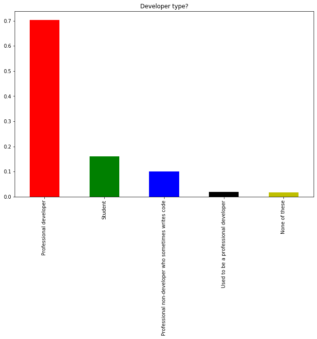

```python
#plotting each Professional status
bar_chart_plot(df, "Professional", "Developer type?")
```

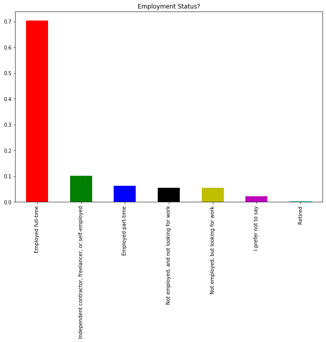

```python
#Plotting Employment status
bar_chart_plot(df, "EmploymentStatus", "Employment Status?")
```

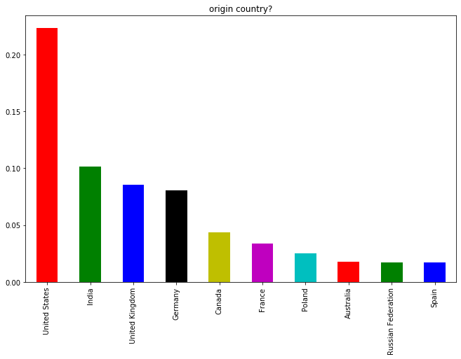

```python
#plotting origin Country
bar_chart_plot(df, "Country", "origin country?")
```

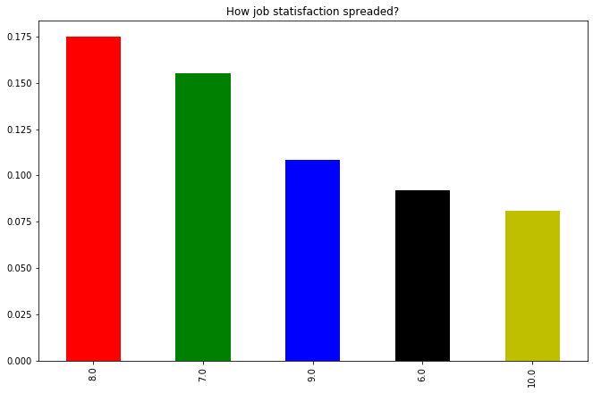

```python
#Plotting jobsatisfaction status
bar_chart_plot(df, "JobSatisfaction", "How job statisfaction spreaded?")
```

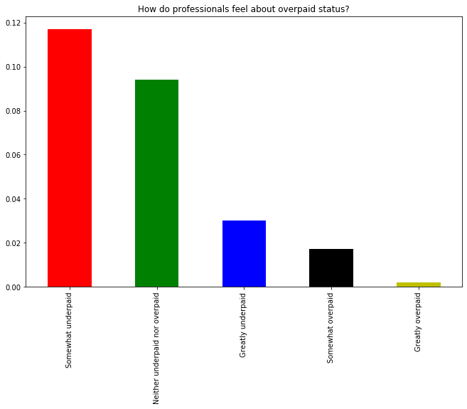

```python
#Plotting salary status
bar_chart_plot(df, "Overpaid", "How do professionals feel about overpaid status?")
```

### Data preparation

Here I will devide the data columns from "Countries" int to Western, Top Asians and rest of the countires.

```python
def country_data(df):
    '''

    Return a dataframe with country seperated

    Parameters:
    df: a dataframe

    Returns:
    df: a dataframe with a new column

    '''
    # For Categorical variables "Country", we seperate them into
    # three sessions: western, asian and other

    western = ['United States', 'Liechtenstein', 'Switzerland',
           'Iceland', 'Norway', 'Israel', 'Denmark',
           'Ireland', 'Canada', 'United Kingdom', 'Germany',
           'Netherlands', 'Sweden', 'Luxembourg', 'Austria',
           'Finland', 'France', 'Belgium', 'Spain', 'Italy',
           'Poland']

    top_asians = ['India', 'Thailand', 'Singapore', 'Hong Kong',
           'South Korea', 'Japan', 'China',
           'Taiwan', 'Malaysia', 'Indonesia', 'Vietnam']
    rest_asians = ['Malaysia', 'Indonesia', 'Vietnam', 'Sri Lanka', 'Pakistan', 'Bangladesh']

    #Add a new catagory seperating to western and eastern
    df['west_or_asians'] = df['Country'].apply(lambda x: 'western' if x in western else ('top_asians' if x in top_asians else ('rest_asians' if x in rest_asians else 'other')))

    return df
```

Here I will select some useful columns for the analysis.

- Country: Country they are living
- YearsCodingJob: Years they are coding
- JobSatisfaction & CareerSatisfaction: do they satisfied with their job and career
- EmploymentStatus: Their employment status
- Salary: Their Salary

I will especially focus on full-time employed professional developer.

```python
#function  to create a dataframe
def data_prep(df):
    '''

    Return useful columns with query condition

    Parameters:
    df: a raw data dataframe

    Returns:
    useful_df: a filtered dataframe with only useful columns

    '''
    #Getting some useful columns for analysis
    usefull_col = ['Country', 'YearsCodedJob', 'EmploymentStatus', 'CareerSatisfaction', 'JobSatisfaction', 'JobSeekingStatus', 'HoursPerWeek', 'Salary', 'west_or_asians', 'Overpaid']
    usefull_df = pd.DataFrame(df.query("Professional == 'Professional developer' and (Gender == 'Male' or Gender == 'Female') and EmploymentStatus == 'Employed full-time'"))[usefull_col]
    return usefull_df
```

```python
#create a dataframe to work upon and analysis
d_df = country_data(df)
d_df.head(5)
usefull_df = data_prep(d_df)

usefull_df.shape
```

```
(21392, 10)
```

```python
usefull_df.head(5)
```

|  | Country | YearsCodedJob | EmploymentStatus | CareerSatisfaction | JobSatisfaction | JobSeekingStatus | HoursPerWeek | Salary | west_or_asians | Overpaid |
| --- | --- | --- | --- | --- | --- | --- | --- | --- | --- | --- |
| 2 | United Kingdom | 20 or more years | Employed full-time | 8.0 | 9.0 | NaN | NaN | 113750.0 | western | Neither underpaid nor overpaid |
| 7 | Poland | 7 to 8 years | Employed full-time | 7.0 | 7.0 | I'm not actively looking, but I am open to new... | 1.0 | NaN | western | NaN |
| 8 | Colombia | 7 to 8 years | Employed full-time | 6.0 | 6.0 | I am not interested in new job opportunities | 2.0 | NaN | other | Neither underpaid nor overpaid |
| 13 | Germany | 15 to 16 years | Employed full-time | 8.0 | 6.0 | I am actively looking for a job | 3.0 | NaN | western | NaN |
| 14 | United Kingdom | 20 or more years | Employed full-time | 8.0 | 8.0 | NaN | NaN | 100000.0 | western | Somewhat underpaid |

For categorical variable Overpaid, we transfer it to calculatable integer value because we want to find out the mean of their opinion.

```python
def underpaid_check(df):
    """

    Parameters:
    df: a dataframe

    Returns:
    dataframe: a converted dataframe with Overpaid column

    """
    pay_mapping = {
        'Greatly underpaid' : 1,
        'Somewhat underpaid' : 2,
        'Neither underpaid nor overpaid' : 3,
        'Somewhat overpaid' : 4,
        'Greatly overpaid' : 5,
        np.nan: np.nan
    }
    df['Overpaid'] = df['Overpaid'].apply(lambda x: np.nan if x == np.nan else pay_mapping[x] )

    return df
```

```python
#Compare selected indicators between western and asians region
usefull_df = underpaid_check(usefull_df)
compared = usefull_df.groupby(['west_or_asians','YearsCodedJob']).mean()
compared
```

| west_or_asians | YearsCodedJob | CareerSatisfaction | JobSatisfaction | HoursPerWeek | Salary | Overpaid |
| --- | --- | --- | --- | --- | --- | --- |
| other | 1 to 2 years | 7.580713 | 6.938947 | 3.620155 | 15285.012047 | 2.325991 |
|  | 10 to 11 years | 7.572093 | 6.971963 | 2.422018 | 37352.137180 | 2.537736 |
|  | 11 to 12 years | 7.784946 | 7.451613 | 2.020408 | 44594.268048 | 2.452381 |
|  | 12 to 13 years | 7.563218 | 7.091954 | 1.128205 | 45421.865805 | 2.333333 |
|  | 13 to 14 years | 7.625000 | 7.265625 | 2.137931 | 47173.009924 | 2.703704 |
| ... | ... | ... | ... | ... | ... | ... |
| western | 6 to 7 years | 7.644114 | 7.177267 | 2.211039 | 69648.807261 | 2.446512 |
|  | 7 to 8 years | 7.532209 | 7.179724 | 2.138060 | 70236.572056 | 2.431525 |
|  | 8 to 9 years | 7.558304 | 7.072438 | 2.096491 | 76314.628263 | 2.432927 |
|  | 9 to 10 years | 7.476000 | 6.988000 | 2.148026 | 74142.281505 | 2.430524 |
|  | Less than a year | 7.811526 | 7.648438 | 1.818627 | 47639.855006 | 2.510870 |

79 rows × 5 columns

column 'YearsCodedJob' will be transferred to calculatable integer value because we want to find out the mean of how long they have been coded.

```python
def handlingExp(df):
    """
    Convert the working year to integer

    Parameters:
    df: a dataframe

    Returns:
    dataframe: a converted dataframe with YearsCodedJob column

    """
    exp_mapping = {'1 to 2 years' : 1,
                '10 to 11 years' : 10,
                '11 to 12 years' : 11,
                '12 to 13 years' : 12,
                '13 to 14 years' : 13,
                '14 to 15 years' : 14,
                '15 to 16 years' : 15,
                '16 to 17 years' : 16,
                '17 to 18 years' : 17,
                '18 to 19 years' : 18,
                '19 to 20 years' : 19,
                '2 to 3 years' : 2,
                '20 or more years' : 20,
                '3 to 4 years' : 3,
                '4 to 5 years' : 4,
                '5 to 6 years' : 5,
                '6 to 7 years' : 6,
                '7 to 8 years' : 7,
                '8 to 9 years' : 8,
                '9 to 10 years' : 9,
                'Less than a year' : 0}

    df_graph = df.reset_index()
    df_graph['YearsCodedJob'] = df_graph['YearsCodedJob'].apply(lambda x: exp_mapping[x])
    df_graph['YearsCodedJob'] = pd.to_numeric(df_graph['YearsCodedJob'])

    return df_graph
```

```python
compared_graph = handlingExp(compared)
compared_graph = compared_graph.sort_values(by='YearsCodedJob')


compared_graph.set_index('YearsCodedJob', inplace=True)
```

```python
compared_graph.head()
```

| YearsCodedJob | west_or_asians | CareerSatisfaction | JobSatisfaction | HoursPerWeek | Salary | Overpaid |
| --- | --- | --- | --- | --- | --- | --- |
| 0 | western | 7.811526 | 7.648438 | 1.818627 | 47639.855006 | 2.510870 |
| 0 | top_asians | 6.597087 | 6.053140 | 5.245455 | 8815.787890 | 2.434211 |
| 0 | rest_asians | 6.166667 | 5.833333 | 2.000000 | 4922.459785 | 2.250000 |
| 0 | other | 7.257143 | 6.980952 | 3.478723 | 12640.598811 | 2.330508 |
| 1 | western | 7.585460 | 7.152713 | 2.216606 | 48332.625897 | 2.381868 |

### Its time to evaluate the analysis, based on our questions

### Result of 1st question

1st question is about better countries to work for a developer. For that we will compare the salaries of developers against their years of experience to find out which region has better potential.

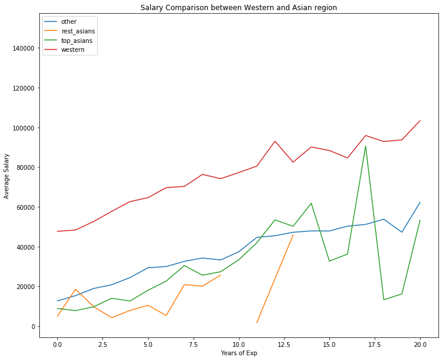

```python
#Plot the Salary Comparison
plt.figure(figsize=(12,10))
compared_graph.groupby('west_or_asians')['Salary'].plot(legend=True)

plt.title("Salary Comparison between Western and Asian region");
plt.xlabel('Years of Exp')
plt.ylabel('Average Salary')
```

As we could see above, Western countries pay better salary to their developers as compared to other parts of the world.

### Result of 2nd question

2nd question is about pay scale difference for developers. For that we will compare the overpaid status of developers against their years of experience to find out which region has better potentials. Overpaid status will tell if they feel good about about their remuneration or not.

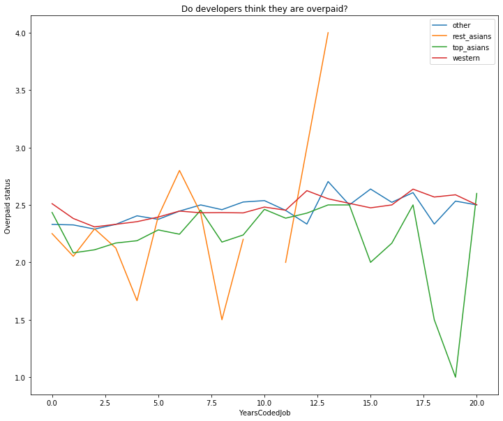

```python
#Plot the overpaid status
plt.figure(figsize=(12,10))
compared_graph.groupby('west_or_asians')['Overpaid'].plot(legend=True)

plt.title("Do developers think they are overpaid?");
plt.xlabel('YearsCodedJob')
plt.ylabel('Overpaid status')
```

Result is pretty interesting. As we could see above the "rest_asian" countries's developers said that they are somehow better paid than "Top_Asians" countries but their salary is lesser than Top Asian region's developers.

### Result of 3rd question

3rd question is about Job Satisfaction for a developer. For that we will compare the job satisfaction status of developers against their years of experience to find out which region has better score.

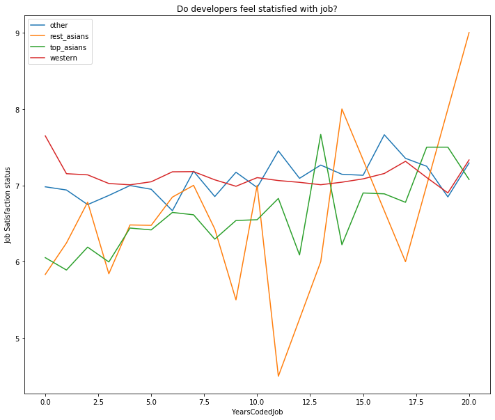

```python
#Plot the JobSatisfaction status
plt.figure(figsize=(12,10))
compared_graph.groupby('west_or_asians')['JobSatisfaction'].plot(legend=True)

plt.title("Do developers feel statisfied with job?");
plt.xlabel('YearsCodedJob')
plt.ylabel('Job Satisfaction status')
```

Here we can see developers from Western region and other parts of the world are satisfied with their job on an average scale as compared to their counterparts from Asian countries in the beginning of their job. After some 18 years in job, Rest_Asian countries data improves a lot than others, while others go to same level on an average.

Final observation is gonna be so much interesting to know which part of the world is better.

### Result of 4th question

4th question is about Career Satisfaction for a developer. For that we will compare the career satisfaction status of developers against their years of experience to find out which region has better potential.

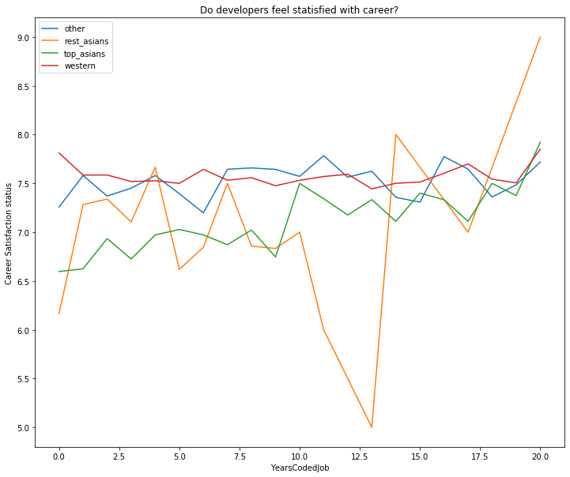

```python
#Plot the CareerSatisfaction status
plt.figure(figsize=(12,10))
compared_graph.groupby('west_or_asians')['CareerSatisfaction'].plot(legend=True)

plt.title("Do developers feel statisfied with career?");
plt.xlabel('YearsCodedJob')
plt.ylabel('Career Satisfaction status')
```

Here we can see developer from Western region and other parts of the world are satisfied with thier career on an average scale as compared to their counterparts from Asian countries in the beginning of their job. After some 18 years in job, Rest_Asian countries data improves a lot than others, while others go to same level on an average.

### Combined analysis of Job and Career satisfaction for developers from western and asian countries

```python
compared.groupby('west_or_asians').mean().CareerSatisfaction
```

```
west_or_asians
other          7.522756
rest_asians    7.013517
top_asians     7.123803
western        7.576207
Name: CareerSatisfaction, dtype: float64
```

```python
compared.groupby('west_or_asians').mean().JobSatisfaction
```

```
west_or_asians
other          7.086955
rest_asians    6.495799
top_asians     6.623020
western        7.122752
Name: JobSatisfaction, dtype: float64
```

```python
compared.groupby('west_or_asians').mean().Salary/50
```

```
west_or_asians
other           748.520605
rest_asians     499.923179
top_asians      627.927284
western        1529.287081
Name: Salary, dtype: float64
```

[figure not shown]

```python
#Plot Comparison of Career and Job Satisfaction between Western and Eastern
plt.figure(figsize=(12,10))
plt.scatter(compared.groupby('west_or_asians').mean().CareerSatisfaction, compared.groupby('west_or_asians').mean().JobSatisfaction, compared.groupby('west_or_asians').mean().Salary/50, c=['blue','red', 'green','magenta'])

plt.title('Comparison of Career and Job Satisfaction\n(Blue: Top_Asians; Red: rest_asians, Green: Other; Magenta: Western)')
plt.xlabel('Career Satisfaction')
plt.ylabel('Job Satisfaction')
```

### Conclusion

-After combining Salary, Job Satisfaction and Career Satisfaction against their years of exp in coding, developers feel better satisfied with career and job from western countries as compared to others.

### Final Observation

Keeping Salary, Job Satisfaction, Career Satisfaction and other factors against their years of exp in coding in mind, Western part of the world is a better place to work for a developer.

```python
!!jupyter nbconvert *.ipynb
```

```
['[NbConvertApp] Converting notebook Write_a_Data_Science_Blog.ipynb to html',
 '[NbConvertApp] Writing 773000 bytes to Write_a_Data_Science_Blog.html']
```